# (Communicate Data Finding : Ford GoBike System Data)

## by (Eng.Mohamed Mostafa)

## Preliminary Wrangling

> bicycle sharing system in California's San Francisco Bay Area. It is operated by Motivate in a partnership with the Metropolitan Transportation Commission and the Bay Area Air Quality Management District. Bay Wheels is the first regional and large-scale bicycle sharing system deployed in California and on the West Coast of the United States. It was established as Bay Area Bike Share in August 2013. As of January 2018, the Bay Wheels system had over 2,600 bicycles in 262 stations across San Francisco, East Bay and San Jose.

### What is the structure of your dataset?

> there are 174,952 records in the dataset with 12 features ( duration_sec , start_time , end_time , start_station_id , start_station_name , end_station_id , end_station_name , bike_id , user_type , member_birth_year , member_gender, age)

### What is/are the main feature(s) of interest in your dataset?

> what is the avarage age of users?

> what is the most user type ?

> what is the most gender ?

> what the relationshipe between Age and trip duration ?

> what the relationshipe between Age and trip duration with gender ?

### What features in the dataset do you think will help support your investigation into your feature(s) of interest?

> Trip Duration (seconds), Start Time and Date , End Time and Date, User Type , Member Year of Birth , Member Gender , age

## Univariate Exploration

> In this section, investigate distributions of individual variables. If you see unusual points or outliers, take a deeper look to clean things up and prepare yourself to look at relationships between variables.

### figure 1 : " what is the avarage age of users ?"

```
(10.0, 100.0, 0.0, 55000.0)
```

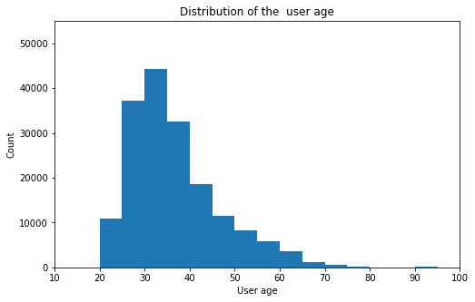

```python
# Here we plot the distribution of age .
binsize = 5
bins = np.arange(0, df['age'].max()+binsize, binsize)

plt.figure(figsize=[8, 5])
plt.hist(data = df, x = 'age', bins = bins)
plt.title('Distribution of the  user age')
plt.xlabel('User age')
plt.ylabel('Count')
plt.axis([10, 100, 0, 55000])
```

> We can see the the above plot is right-screwed, with a long tail on the right.

> the most user age from 30 :35 years

### figure 2 : " what is the most user type ?"

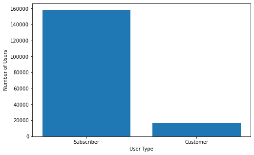

```python
# plotting types of users on bar.
plt.figure(figsize=[8,5])
plt.bar(x = df.user_type.value_counts().keys(), height = df.user_type.value_counts() )
plt.xlabel('User Type')
plt.ylabel('Number of Users')
```

> We can see the the above plot is subscriber is the most user type

### figure 3 : " what is the most gender ?"

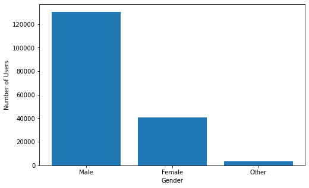

```python
# plotting genders on bar.
plt.figure(figsize=[8,5])
plt.bar(x = df.member_gender.value_counts().keys(), height = df.member_gender.value_counts() )
plt.xlabel('Gender')
plt.ylabel('Number of Users')
```

> We can see the the above plot is male is the most Gender

## Bivariate Exploration

> we will see the correlation between (trip duration) and (age).

### figure 4 : " what the relationshipe between Age and trip duration ?"

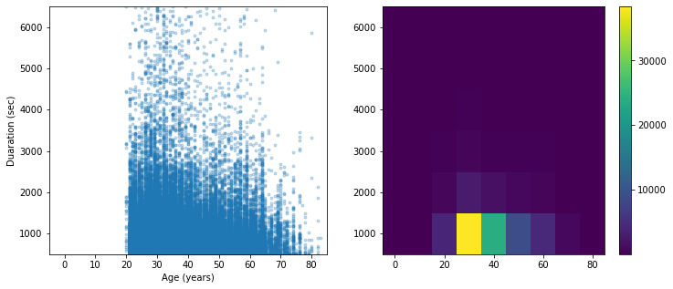

```python
plt.figure(figsize=[12,5])

plt.subplot(1, 2, 1)
plt.scatter(df['age'], df['duration_sec'], alpha = 0.25, marker = '.' )
plt.axis([-5, 85, 500, 6500])
plt.xlabel('Age (years)')
plt.ylabel('Duaration (sec)')

plt.subplot(1, 2, 2)
bins_y = np.arange(500, 6500+1, 1000)
bins_x = np.arange(-5, 85+1, 10)
plt.hist2d(df['age'], df['duration_sec'],
           bins = [bins_x, bins_y])
plt.colorbar(ticks=[10000, 20000, 30000, 40000]);
plt.show()
```

## Multivariate Exploration

### figure 6 : " what the relationshipe between Age and trip duration with gender ?"

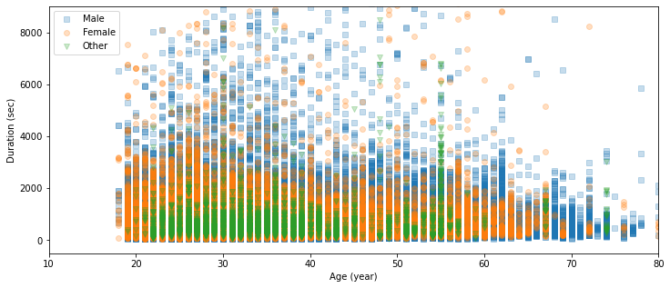

```python
plt.figure(figsize=[12,5])
gender_markers = [['Male', 's'],['Female', 'o'],['Other', 'v']]

for gender, marker in gender_markers:
    df_gender = df[df['member_gender'] == gender]
    plt.scatter((2019 - df_gender['member_birth_year']), df_gender['duration_sec'], marker = marker, alpha=0.25)
plt.legend(['Male','Female','Other'])
plt.axis([10, 80, -500, 9000 ])
plt.xlabel('Age (year)')
plt.ylabel('Duration (sec)')
plt.show()
```

### Talk about some of the relationships you observed in this part of the investigation. Were there features that strengthened each other in terms of looking at your feature(s) of interest?

> it is clear in above figure the male is the most than the female

### Were there any interesting or surprising interactions between features?

> but also the ratio of the female from the total female > the ratio of the male from total male